# Case-study Right heart catheterization

Hanchao Zhang, M.S.

## Motivation

Right heart catheterization (RHC), also known as pulmonary artery catheterization, is an invasive test that mainly checks the working state of the heart by guiding a pulmonary artery (PA) catheter (a small and hollow tube) through the pulmonary artery and into the right chambers of the heart. By this way, the catheter can measure the functions of the heart such as blood pressure, cardiac output, etc., including other measures in connection to heart problems such as diurnal respiratory instability according to one study by Kumagai, et al. (2018). In turn, these measurements are used to treat and manage heart conditions such as heart failure, congenital heart disease, cardiomyopathy, pulmonary hypertension, etc. Thus, many cardiologists and critical care physicians believe that the direct measurements of the cardiac functions by RHC is necessary to the management of treating critically ill patients and that such management will theoretically lead to better health outcomes according to Connors, et al. (1996). However, due to the severity of the cardiac conditions of the patients as well as the invasive procedure of RHC with no guarantee of any beneficial outcomes, data measuring the benefits of the RHC procedure cannot easily be collected in a randomized control trial (RCT). To make up for this, observational studies were used to evaluate the effectiveness of the RHC procedure. Although, these studies are

susceptible to treatment selection bias as physicians can make the decision to use or withhold RHC in the treatment of their patients.

The purpose of this study is to reproduce the statistical analysis of the objective of the research, The Effectiveness of Right Heart Catheterization in the Initial Care, using the data it collected from a large group of critically ill patients and in predefined patient subgroups in order to determine how valid is the association between the use of the right heart catheterization during the first 24 hours of an ICU stay with subsequent survival, length of stay, intensity of care, and cost of care.

You can find the description of the data from http://biostat.mc.vanderbilt.edu/wiki/pub/Main/DataSets/rhc.html

## Data preparation

By reading the description of the data, we need to exclude several variables in the dataset. The variables including all the enrollment time, discharge time and so on, and the variables with percentage of missing value larger than 20% are also excluded.

We choose 20% as an arbitrary number since we do not want to lose too much information from the whole data set.

```r
rhc <- read.csv("http://biostat.mc.vanderbilt.edu/wiki/pub/Main/DataSets/rhc.csv")
rhc <- rhc[,-1]
var.vector <- c(
"cat2",
"sadmdte",
"dschdte",
"dthdte",
"lstctdte",
"death",
"surv2md1",
"ptid"
)
var.which <- NULL
for (i in var.vector) {
  var.which[i] <- which(names(rhc) == i)
}

var.which2 <- NULL
for (i in names(rhc)) {
  if( sum(is.na(rhc[,i]))/nrow(rhc) > 0.2 ){
    var.which2[i] <- which(names(rhc) == i)
  }
}

rhc_DF <- rhc[,-c(var.which, var.which2)]
```

```r
summary(rhc_DF)
```

```
##                 cat1               ca          cardiohx
##  ARF              :2490   Metastatic: 384   Min.   :0.0000
##  MOSF w/Sepsis    :1227   No        :4379   1st Qu.:0.0000
##  COPD             : 457   Yes       : 972   Median :0.0000
##  CHF              : 456                     Mean   :0.1766
##  Coma             : 436                     3rd Qu.:0.0000
##  MOSF w/Malignancy: 399                     Max.   :1.0000
##  (Other)          : 270
##      chfhx          dementhx          psychhx           chrpulhx
##  Min.   :0.000   Min.   :0.00000   Min.   :0.00000   Min.   :0.0000
##  1st Qu.:0.000   1st Qu.:0.00000   1st Qu.:0.00000   1st Qu.:0.0000
##  Median :0.000   Median :0.00000   Median :0.00000   Median :0.0000
##  Mean   :0.178   Mean   :0.09834   Mean   :0.06731   Mean   :0.1899
##  3rd Qu.:0.000   3rd Qu.:0.00000   3rd Qu.:0.00000   3rd Qu.:0.0000
##  Max.   :1.000   Max.   :1.00000   Max.   :1.00000   Max.   :1.0000
##
##     renalhx           liverhx           gibledhx          malighx
##  Min.   :0.00000   Min.   :0.00000   Min.   :0.00000   Min.   :0.0000
##  1st Qu.:0.00000   1st Qu.:0.00000   1st Qu.:0.00000   1st Qu.:0.0000
##  Median :0.00000   Median :0.00000   Median :0.00000   Median :0.0000
##  Mean   :0.04446   Mean   :0.06992   Mean   :0.03226   Mean   :0.2295
##  3rd Qu.:0.00000   3rd Qu.:0.00000   3rd Qu.:0.00000   3rd Qu.:0.0000
##  Max.   :1.00000   Max.   :1.00000   Max.   :1.00000   Max.   :1.0000
##
##     immunhx         transhx           amihx              age
##  Min.   :0.000   Min.   :0.0000   Min.   :0.00000   Min.   : 18.04
##  1st Qu.:0.000   1st Qu.:0.0000   1st Qu.:0.00000   1st Qu.: 50.15
##  Median :0.000   Median :0.0000   Median :0.00000   Median : 64.05
##  Mean   :0.269   Mean   :0.1154   Mean   :0.03487   Mean   : 61.38
##  3rd Qu.:1.000   3rd Qu.:0.0000   3rd Qu.:0.00000   3rd Qu.: 73.93
##  Max.   :1.000   Max.   :1.0000   Max.   :1.00000   Max.   :101.85
##
##      sex            edu           das2d3pc         t3d30       dth30
##  Female:2543   Min.   : 0.00   Min.   :11.00   Min.   : 2.00   No :3817
##  Male  :3192   1st Qu.:10.00   1st Qu.:16.06   1st Qu.:16.00   Yes:1918
##                Median :12.00   Median :19.75   Median :30.00
##                Mean   :11.68   Mean   :20.50   Mean   :23.61
##                3rd Qu.:13.00   3rd Qu.:23.43   3rd Qu.:30.00
##                Max.   :30.00   Max.   :33.00   Max.   :30.00
##
```

[output cut: 49 more lines]

```
##  No :5381   No :4704   No :5683   No :5728   black: 920
##  Yes: 354   Yes:1031   Yes:  52   Yes:   7   other: 355
##                                              white:4460
##
##
##
##
##         income
##  > $50k    : 451
##  $11-$25k  :1165
##  $25-$50k  : 893
##  Under $11k:3226
##
##
##
```

```r
str(rhc_DF)
```

```
## 'data.frame':    5735 obs. of  52 variables:
##  $ cat1    : Factor w/ 9 levels "ARF","CHF","Cirrhosis",..: 6 9 8 1 9 6 8 1 8 1 ...
##  $ ca      : Factor w/ 3 levels "Metastatic","No",..: 3 2 3 2 2 2 1 2 3 3 ...
##  $ cardiohx: int  0 1 0 0 0 0 0 0 0 0 ...
##  $ chfhx   : int  0 1 0 0 0 1 0 0 0 0 ...
##  $ dementhx: int  0 0 0 0 0 0 0 0 0 0 ...
##  $ psychhx : int  0 0 0 0 0 0 0 0 0 0 ...
##  $ chrpulhx: int  1 0 0 0 0 1 0 0 0 0 ...
##  $ renalhx : int  0 0 0 0 0 0 0 0 0 0 ...
##  $ liverhx : int  0 0 0 0 0 0 0 0 0 0 ...
##  $ gibledhx: int  0 0 0 0 0 0 0 0 0 0 ...
##  $ malighx : int  1 0 1 0 0 0 1 0 0 1 ...
##  $ immunhx : int  0 1 1 1 0 0 0 0 0 0 ...
##  $ transhx : int  0 1 0 0 0 0 0 1 0 0 ...
##  $ amihx   : int  0 0 0 0 0 0 0 0 0 0 ...
```

[output cut: 38 more lines]

Changing the type of the data is also very important for survival analysis, and by checking the data, we also sometimes need to deal with variables with characters. In our data set, the status of having RHC or not is denoted with character. A way to adjust it is to directly force it into factor. However, this kind of factor format sometimes does not work in some of the packages in R. Therefore, we forced the character into a numeric number and deducted it by 1.

```r
for (i in names(rhc_DF)) {
  if(is.numeric(rhc_DF[,i])){
    if(mean(rhc_DF[,i], na.rm = T) < 5){
      rhc_DF[,i] <- as.factor((rhc_DF[,i]))
    }else{
      rhc_DF[,i] <- ((rhc_DF[,i]))
    }
  }
}
rhc_DF$dth30 <- as.numeric(rhc_DF$dth30) - 1
rhc_DF$swang1 <- as.numeric(rhc_DF$swang1) - 1
table(rhc_DF$swang1)
```

```
##
##    0    1
## 3551 2184
```

## Analysis

### Cox model and (Survival Random Forest)

After cleaning the data, we can fit the cox model and survival random forest with our data

```r
fit1 <- coxph(Surv(t3d30,dth30) ~ . ,data = rhc_DF)
fit2 <- rfsrc(Surv(t3d30,dth30) ~ ., data = rhc_DF, nsplit = 10, importance = TRUE, ntree = 100)
```

We can definitely compute cross-validation test error by our own code. However, for the survival analysis, the ‘pec’ package save us lots of effort to do the cross-validation and also the function is faster.

```r
full <- Surv(t3d30,dth30) ~ 1

fitpec1 <- pec(list("Cox" = fit2), formula =full, data = rhc_DF, cens.model = 'cox', splitMethod = "cv3", keep.index = TRUE, keep.matrix = TRUE)
```

```
## No covariates  specified: Kaplan-Meier for censoring times used for weighting.
```

```
## 1
```

```
## 2
```

```
## 3
```

### Restricted Mean Survival time (Causual Inference)

Causal inference is the process of drawing a conclusion about a causal connection based on the conditions of the occurrence of an effect. The main difference between causal inference and inference of association is that the former analyzes the response of the effect variable when the cause is changed.[1][2] The science of why things occur is called etiology. Causal inference is an example of causal reasoning (https://en.wikipedia.org/wiki/Causal_inference)

```r
rhc0 <- rhc1 <- rhc_DF
rhc0$swang1 <- 0
rhc1$swang1 <- 1
```

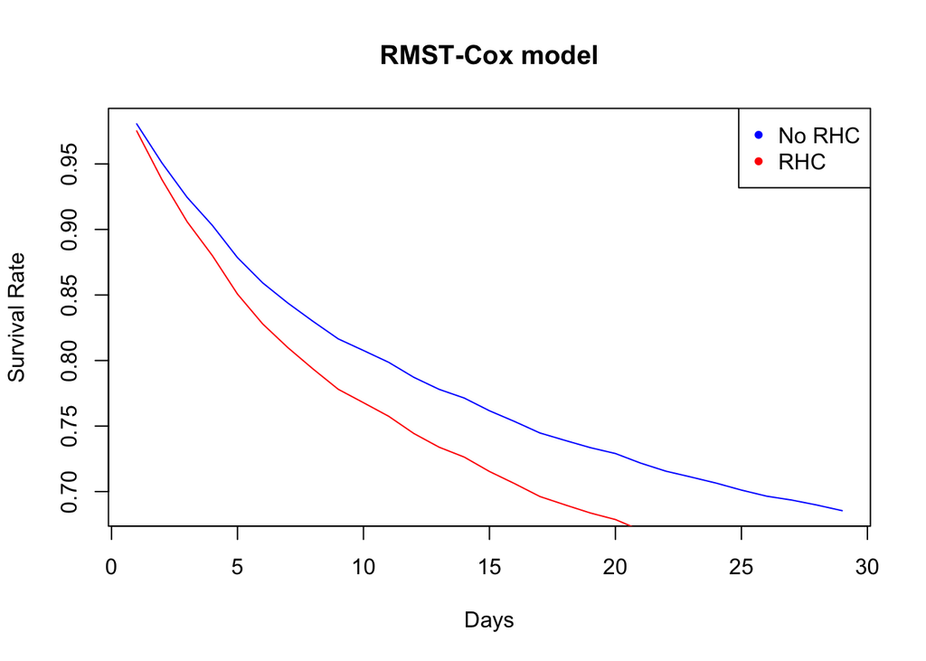

```r
time1 <- survfit(fit1, newdata = rhc0)$surv
time2 <- survfit(fit1, newdata = rhc1)$surv

rowMeans(time1) %>%
  plot(type = "l", col = "blue", main = 'RMST-Cox model', xlab = 'Days', ylab = 'Survival Rate')
rowMeans(time2) %>%
  lines(col = "red")
legend('topright', c('No RHC','RHC'), col = c('blue','red'), pch = 20)
```

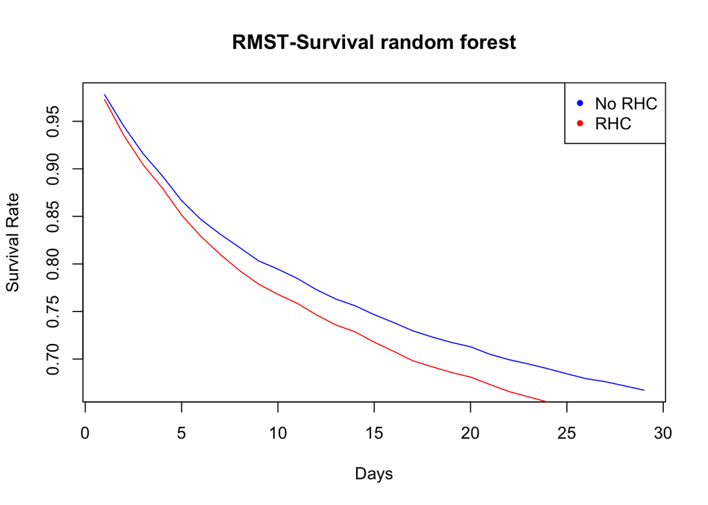

```r
time3 <- predict(fit2, newdata = rhc0)$survival
time4 <- predict(fit2, newdata = rhc1)$survival


colMeans(time3) %>%
  plot(type = "l", col = "blue", main = 'RMST-Survival random forest', xlab = 'Days', ylab = 'Survival Rate')
colMeans(time4) %>%
  lines(col = "red")
legend('topright', c('No RHC','RHC'), col = c('blue','red'), pch = 20)
```